```python
import pandas as pd
import matplotlib.pyplot as plt
import seaborn as sns
import numpy as np
from sklearn.model_selection import train_test_split

import torch
from torch import nn
import torch.nn.functional as F
from torch.utils.data import DataLoader
import pytorch_lightning as pl
import torchmetrics
from pytorch_lightning.callbacks import TQDMProgressBar

from tqdm import tqdm

%matplotlib inline
```

# 1 Feed-forward Neural Network for Binary Classification

## 1 - a. Data preprocessing and exploratory data analysis.

#### Load data

```python
df = pd.read_csv('BRCA-prognosis-train.csv')
df
```

|  | brca1 | brca2 | palb2 | pten | tp53 | atm | cdh1 | chek2 | nbn | nf1 | ... | ppp2cb_mut | smarcd1_mut | nras_mut | ndfip1_mut | hras_mut | prps2_mut | smarcb1_mut | stmn2_mut | siah1_mut | outcome |
| --- | --- | --- | --- | --- | --- | --- | --- | --- | --- | --- | --- | --- | --- | --- | --- | --- | --- | --- | --- | --- | --- |
| 0 | 0.6522 | -1.0002 | 0.2878 | 0.4661 | -1.1925 | 1.2016 | -0.7379 | -0.5657 | 0.5885 | 1.0009 | ... | 0 | 0 | 0 | 0 | 0 | 0 | 0 | 0 | 0 | 0 |
| 1 | -1.1329 | 2.7485 | -0.7175 | 0.9446 | -0.2574 | -1.2881 | -0.9623 | -0.4673 | 0.2962 | -0.9181 | ... | 0 | 0 | 0 | 0 | 0 | 0 | 0 | 0 | 0 | 1 |
| 2 | -0.6247 | 0.9146 | -0.0536 | -0.0933 | 0.0326 | -1.7125 | -1.0493 | -0.6886 | -0.5311 | -1.7056 | ... | 0 | 0 | 0 | 0 | 0 | 0 | 0 | 0 | 0 | 0 |
| 3 | 0.5877 | -2.2261 | 2.4252 | -0.6472 | -1.7071 | 0.8207 | -0.4278 | 3.4991 | -0.5951 | -1.0470 | ... | 0 | 0 | 0 | 0 | 0 | 0 | 0 | 0 | 0 | 0 |
| 4 | -0.2048 | -1.2539 | -1.7408 | 0.2214 | -0.0545 | 0.9722 | 0.8895 | 0.9785 | -0.3633 | -1.1611 | ... | 0 | 0 | 0 | 0 | 0 | 0 | 0 | 0 | 0 | 1 |
| ... | ... | ... | ... | ... | ... | ... | ... | ... | ... | ... | ... | ... | ... | ... | ... | ... | ... | ... | ... | ... | ... |
| 1399 | -0.8468 | 0.4818 | 0.6131 | 0.0600 | -0.6060 | 1.7714 | 0.8917 | 0.1010 | -0.8821 | -0.7944 | ... | 0 | 0 | 0 | 0 | 0 | 0 | 0 | 0 | 0 | 1 |
| 1400 | -0.1844 | 0.0005 | 0.3751 | -0.7222 | -1.8560 | 0.7996 | 0.1025 | 0.7319 | 2.6620 | -0.0314 | ... | 0 | 0 | 0 | 0 | 0 | 0 | 0 | 0 | 0 | 0 |
| 1401 | 1.4376 | -0.3174 | 1.3291 | 0.4604 | 0.7625 | -0.3105 | -2.8114 | 0.1046 | 0.7327 | 0.1248 | ... | 0 | 0 | 0 | 0 | 0 | 0 | 0 | 0 | 0 | 0 |
| 1402 | -1.2448 | -2.2417 | 0.5508 | 0.8508 | -0.6159 | 1.5829 | 0.0555 | 1.3599 | -0.5648 | -0.5968 | ... | 0 | 0 | 0 | 0 | 0 | 0 | 0 | 0 | 0 | 1 |
| 1403 | -0.6506 | -0.1476 | -0.7637 | 1.1327 | -0.3060 | -1.4050 | 0.9773 | -0.3467 | -0.8001 | -0.7799 | ... | 0 | 0 | 0 | 0 | 0 | 0 | 0 | 0 | 0 | 1 |

1404 rows × 663 columns

```python
sum(list(df.isnull().sum()))
```

```
0
```

- No missing values in Labeled Data.

### Summary Tables

```python
df.info()
```

```
<class 'pandas.core.frame.DataFrame'>
RangeIndex: 1404 entries, 0 to 1403
Columns: 663 entries, brca1 to outcome
dtypes: float64(489), int64(2), object(172)
memory usage: 7.1+ MB
```

```python
df.describe()
```

|  | brca1 | brca2 | palb2 | pten | tp53 | atm | cdh1 | chek2 | nbn | nf1 | ... | srd5a3 | st7 | star | tnk2 | tulp4 | ugt2b15 | ugt2b17 | ugt2b7 | stmn2_mut | outcome |
| --- | --- | --- | --- | --- | --- | --- | --- | --- | --- | --- | --- | --- | --- | --- | --- | --- | --- | --- | --- | --- | --- |
| count | 1404.000000 | 1404.000000 | 1404.000000 | 1404.000000 | 1404.000000 | 1404.000000 | 1404.000000 | 1404.000000 | 1404.000000 | 1404.000000 | ... | 1404.000000 | 1404.000000 | 1404.000000 | 1404.000000 | 1404.000000 | 1404.000000 | 1404.000000 | 1404.000000 | 1404.0 | 1404.000000 |
| mean | 0.000090 | -0.033844 | 0.024035 | -0.011157 | 0.011936 | 0.025500 | 0.014164 | 0.008059 | 0.011962 | -0.006756 | ... | -0.004123 | -0.004640 | -0.006748 | 0.018110 | 0.006005 | 0.014624 | -0.004813 | -0.002082 | 0.0 | 0.316239 |
| std | 0.989816 | 0.999775 | 0.994332 | 1.008835 | 0.988798 | 0.985012 | 0.988141 | 0.981519 | 1.003056 | 0.976198 | ... | 1.001727 | 0.999874 | 1.002540 | 0.995641 | 0.990767 | 1.048383 | 1.016356 | 0.993098 | 0.0 | 0.465173 |
| min | -2.335600 | -2.708900 | -3.742000 | -5.932800 | -2.481200 | -3.170500 | -3.323700 | -2.688700 | -3.321500 | -2.968600 | ... | -2.719400 | -4.982700 | -2.936400 | -3.833300 | -3.609300 | -1.166900 | -1.798000 | -1.051600 | 0.0 | 0.000000 |
| 25% | -0.723200 | -0.721100 | -0.656775 | -0.575600 | -0.649175 | -0.624225 | -0.441425 | -0.704025 | -0.666425 | -0.670250 | ... | -0.669325 | -0.619375 | -0.634175 | -0.642400 | -0.706800 | -0.512700 | -0.482875 | -0.726525 | 0.0 | 0.000000 |
| 50% | -0.130150 | -0.110750 | 0.004550 | 0.094550 | -0.004450 | 0.030550 | 0.129200 | -0.118950 | 0.001700 | -0.052700 | ... | -0.156000 | -0.053750 | -0.013600 | 0.014300 | -0.027350 | -0.288550 | -0.143650 | -0.424600 | 0.0 | 0.000000 |
| 75% | 0.549875 | 0.590750 | 0.661600 | 0.638850 | 0.655075 | 0.718300 | 0.667350 | 0.554775 | 0.642600 | 0.647425 | ... | 0.495325 | 0.556925 | 0.571425 | 0.664675 | 0.594500 | 0.072425 | 0.266750 | 0.429425 | 0.0 | 1.000000 |
| max | 4.554200 | 3.737900 | 4.615000 | 2.630700 | 4.149200 | 3.824200 | 2.632500 | 3.981500 | 5.371300 | 3.816200 | ... | 6.329000 | 4.571300 | 12.742300 | 3.240300 | 3.661000 | 10.884900 | 12.643900 | 3.284400 | 0.0 | 1.000000 |

8 rows × 491 columns

- 663-491 = 172 features contain non-numeric values (All of them are features related with mutant gene). So I will covert string values in these features into numeric values.

### Clean Data - convert all string values to numeric values

```python
# list features with string values.
col_names_mutGene = list(df.columns[df.columns.str.contains(pat = '_mut')])
col_names_with_mutGene = []
for i in col_names_mutGene:
    k = i[:-4]
    col_names_with_mutGene.append(k)

#  convert all string values in these features to numeric values
for col in col_names_mutGene:
    df[col] = df[col].apply(lambda x: 0 if (x=='0' or x==0) else 1)
```

### Re-do Summary Tables for Labeled Data

```python
df.describe()
```

|  | brca1 | brca2 | palb2 | pten | tp53 | atm | cdh1 | chek2 | nbn | nf1 | ... | ppp2cb_mut | smarcd1_mut | nras_mut | ndfip1_mut | hras_mut | prps2_mut | smarcb1_mut | stmn2_mut | siah1_mut | outcome |
| --- | --- | --- | --- | --- | --- | --- | --- | --- | --- | --- | --- | --- | --- | --- | --- | --- | --- | --- | --- | --- | --- |
| count | 1404.000000 | 1404.000000 | 1404.000000 | 1404.000000 | 1404.000000 | 1404.000000 | 1404.000000 | 1404.000000 | 1404.000000 | 1404.000000 | ... | 1404.000000 | 1404.000000 | 1404.000000 | 1404.000000 | 1404.000000 | 1404.000000 | 1404.000000 | 1404.0 | 1404.000000 | 1404.000000 |
| mean | 0.000090 | -0.033844 | 0.024035 | -0.011157 | 0.011936 | 0.025500 | 0.014164 | 0.008059 | 0.011962 | -0.006756 | ... | 0.001425 | 0.001425 | 0.001425 | 0.000712 | 0.000712 | 0.000712 | 0.001425 | 0.0 | 0.000712 | 0.316239 |
| std | 0.989816 | 0.999775 | 0.994332 | 1.008835 | 0.988798 | 0.985012 | 0.988141 | 0.981519 | 1.003056 | 0.976198 | ... | 0.037729 | 0.037729 | 0.037729 | 0.026688 | 0.026688 | 0.026688 | 0.037729 | 0.0 | 0.026688 | 0.465173 |
| min | -2.335600 | -2.708900 | -3.742000 | -5.932800 | -2.481200 | -3.170500 | -3.323700 | -2.688700 | -3.321500 | -2.968600 | ... | 0.000000 | 0.000000 | 0.000000 | 0.000000 | 0.000000 | 0.000000 | 0.000000 | 0.0 | 0.000000 | 0.000000 |
| 25% | -0.723200 | -0.721100 | -0.656775 | -0.575600 | -0.649175 | -0.624225 | -0.441425 | -0.704025 | -0.666425 | -0.670250 | ... | 0.000000 | 0.000000 | 0.000000 | 0.000000 | 0.000000 | 0.000000 | 0.000000 | 0.0 | 0.000000 | 0.000000 |
| 50% | -0.130150 | -0.110750 | 0.004550 | 0.094550 | -0.004450 | 0.030550 | 0.129200 | -0.118950 | 0.001700 | -0.052700 | ... | 0.000000 | 0.000000 | 0.000000 | 0.000000 | 0.000000 | 0.000000 | 0.000000 | 0.0 | 0.000000 | 0.000000 |
| 75% | 0.549875 | 0.590750 | 0.661600 | 0.638850 | 0.655075 | 0.718300 | 0.667350 | 0.554775 | 0.642600 | 0.647425 | ... | 0.000000 | 0.000000 | 0.000000 | 0.000000 | 0.000000 | 0.000000 | 0.000000 | 0.0 | 0.000000 | 1.000000 |
| max | 4.554200 | 3.737900 | 4.615000 | 2.630700 | 4.149200 | 3.824200 | 2.632500 | 3.981500 | 5.371300 | 3.816200 | ... | 1.000000 | 1.000000 | 1.000000 | 1.000000 | 1.000000 | 1.000000 | 1.000000 | 0.0 | 1.000000 | 1.000000 |

8 rows × 663 columns

### Plot histogram of the tp53 gene expression, tp53 mutant status, map3k1 gene expression, and map3k1_mut status

```
[Text(0.5, 0, 'map3k1 Mutant')]
```

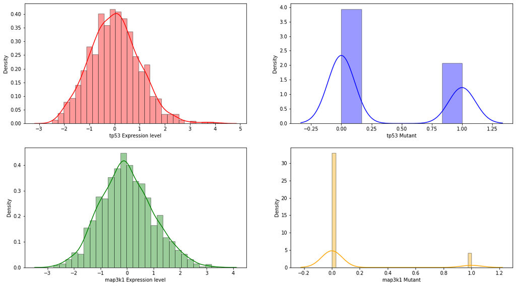

```python
fig, axes = plt.subplots(2, 2, figsize=(18, 10))

tp53 = sns.distplot(df['tp53'], hist = True, hist_kws = {"edgecolor":"black"}, ax=axes[0,0], color = "red")
tp53.set( xlabel = "tp53 Expression level")

tp53_mut = sns.distplot(df['tp53_mut'], hist = True, hist_kws = {"edgecolor":"black"}, ax=axes[0,1], color = "blue")
tp53_mut.set( xlabel = "tp53 Mutant")

map3k1 = sns.distplot(df['map3k1'], hist = True, hist_kws = {"edgecolor":"black"}, ax=axes[1,0], color = "green")
map3k1.set( xlabel = "map3k1 Expression level")

map3k1_mut = sns.distplot(df['map3k1_mut'], hist = True, hist_kws = {"edgecolor":"black"}, ax=axes[1,1], color = "orange")
map3k1_mut.set( xlabel = "map3k1 Mutant")
```

### Boxplot for gene expression of different group ( better prognosis vs worse prognosis ; Non-Mutant vs Mutant )

```python
df_for_box = df[['tp53','tp53_mut','map3k1','map3k1_mut', 'brca2','brca2_mut', 'erbb2', 'erbb2_mut','outcome']].copy()

df_for_box = df_for_box.assign(tp53_mut = np.where(df_for_box['tp53_mut']==0,'Non-Mutant','Mutant'),
                               map3k1_mut = np.where(df_for_box['map3k1_mut']==0,'Non-Mutant','Mutant'),
                               brca2_mut = np.where(df_for_box['brca2_mut']==0,'Non-Mutant','Mutant'),
                               erbb2_mut = np.where(df_for_box['erbb2_mut']==0,'Non-Mutant','Mutant'),
                               outcome = np.where(df_for_box['outcome']==0,'better prognosis','worse prognosis'))

df_for_box
```

|  | tp53 | tp53_mut | map3k1 | map3k1_mut | brca2 | brca2_mut | erbb2 | erbb2_mut | outcome |
| --- | --- | --- | --- | --- | --- | --- | --- | --- | --- |
| 0 | -1.1925 | Non-Mutant | -0.9006 | Non-Mutant | -1.0002 | Non-Mutant | 0.0183 | Non-Mutant | better prognosis |
| 1 | -0.2574 | Non-Mutant | -0.4967 | Non-Mutant | 2.7485 | Non-Mutant | -0.8339 | Non-Mutant | worse prognosis |
| 2 | 0.0326 | Non-Mutant | -0.4701 | Mutant | 0.9146 | Non-Mutant | 0.0019 | Non-Mutant | better prognosis |
| 3 | -1.7071 | Non-Mutant | -1.2749 | Non-Mutant | -2.2261 | Non-Mutant | -0.8575 | Non-Mutant | better prognosis |
| 4 | -0.0545 | Non-Mutant | 0.4572 | Non-Mutant | -1.2539 | Non-Mutant | 0.1026 | Non-Mutant | worse prognosis |
| ... | ... | ... | ... | ... | ... | ... | ... | ... | ... |
| 1399 | -0.6060 | Mutant | -0.1359 | Non-Mutant | 0.4818 | Non-Mutant | -0.7871 | Non-Mutant | worse prognosis |
| 1400 | -1.8560 | Mutant | 0.0691 | Non-Mutant | 0.0005 | Non-Mutant | 1.6321 | Non-Mutant | better prognosis |
| 1401 | 0.7625 | Non-Mutant | 0.4242 | Non-Mutant | -0.3174 | Non-Mutant | -0.4242 | Non-Mutant | better prognosis |
| 1402 | -0.6159 | Mutant | 0.4374 | Non-Mutant | -2.2417 | Non-Mutant | -1.5104 | Non-Mutant | worse prognosis |
| 1403 | -0.3060 | Non-Mutant | -0.0467 | Non-Mutant | -0.1476 | Non-Mutant | 2.2038 | Non-Mutant | worse prognosis |

1404 rows × 9 columns

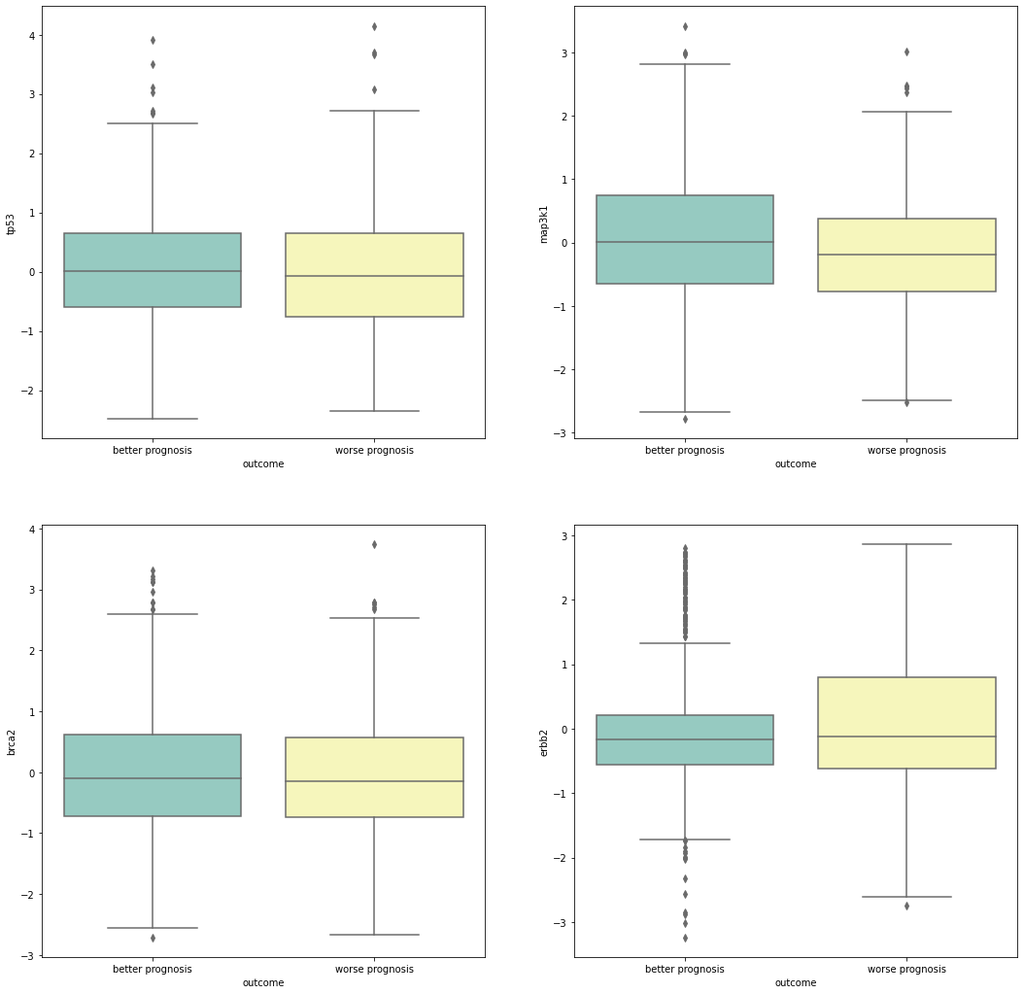

```python
fig, axes = plt.subplots(2, 2, figsize=(18, 18))

tp53 = sns.boxplot(x='outcome', y='tp53', ax=axes[0,0], data=df_for_box, palette='Set3')
map3k1 = sns.boxplot(x='outcome', y='map3k1', ax=axes[0,1], data=df_for_box, palette='Set3')
brca2 = sns.boxplot(x='outcome', y='brca2', ax=axes[1,0], data=df_for_box, palette='Set3')
erbb2 = sns.boxplot(x='outcome', y='erbb2', ax=axes[1,1], data=df_for_box, palette='Set3')
```

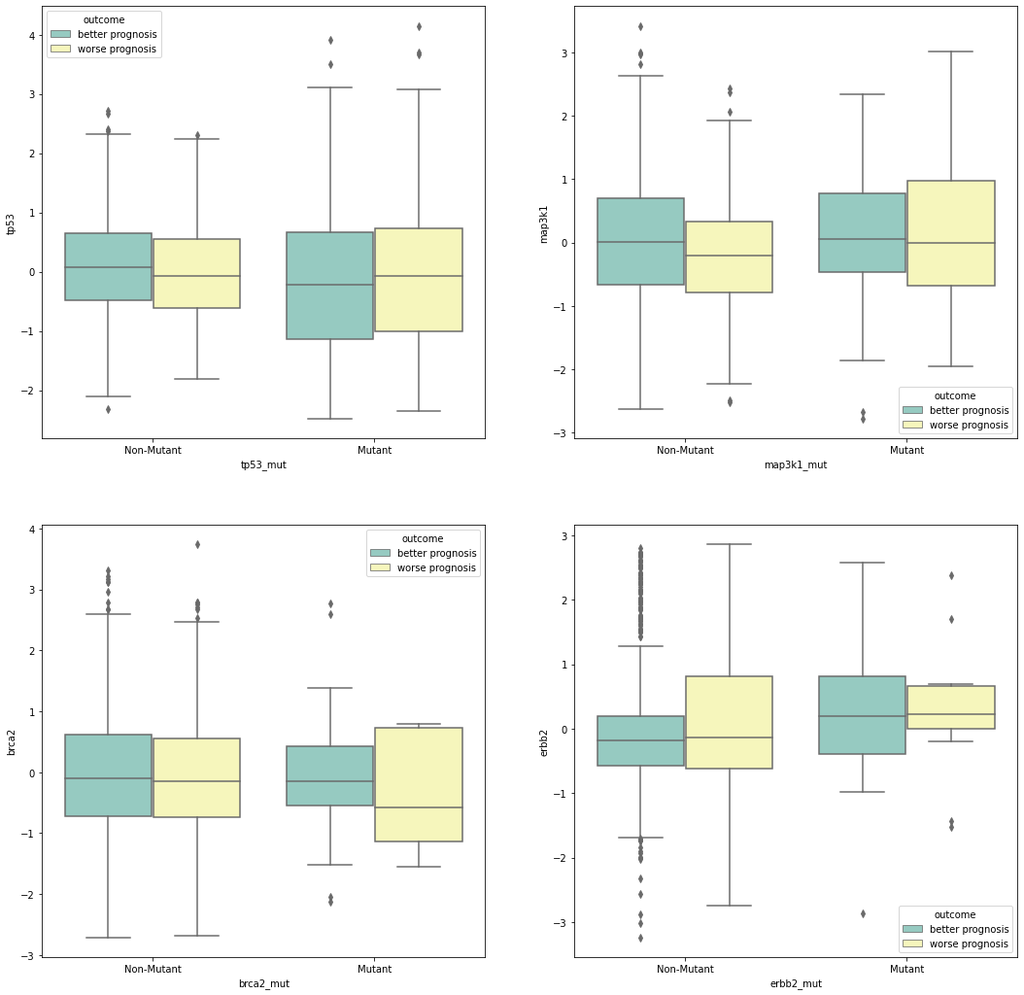

```python
fig, axes = plt.subplots(2, 2, figsize=(18, 18))

tp53 = sns.boxplot(x='tp53_mut', y='tp53', hue='outcome', ax=axes[0,0], data=df_for_box, palette='Set3')
map3k1 = sns.boxplot(x='map3k1_mut', y='map3k1', hue='outcome', ax=axes[0,1], data=df_for_box, palette='Set3')
brca2 = sns.boxplot(x='brca2_mut', y='brca2', hue='outcome', ax=axes[1,0], data=df_for_box, palette='Set3')
erbb2 = sns.boxplot(x='erbb2_mut', y='erbb2', hue='outcome', ax=axes[1,1], data=df_for_box, palette='Set3')
```

### From above summary statistics and plots:

- It seems that labeled data contains too many features in data. (1404 samples vs 662 features)
- Some gene expression doesn't have difference between patients with better prognosis and patients with worse prognosis.
- As results, I will do t-test for all features to find out which features have significant difference (p < 0.05) between patients with better prognosis and patients with worse prognosis.

#### Do t-test for all features:

```python
from scipy import stats
import matplotlib.pyplot as plt
```

```python
# Split data into 2 groups (patients with better prognosis and patients with worse prognosis)
outcome_0 = df[(df['outcome'] == 0)].copy()
outcome_1 = df[(df['outcome'] == 1)].copy()
```

```python
outcome_0
```

|  | brca1 | brca2 | palb2 | pten | tp53 | atm | cdh1 | chek2 | nbn | nf1 | ... | ppp2cb_mut | smarcd1_mut | nras_mut | ndfip1_mut | hras_mut | prps2_mut | smarcb1_mut | stmn2_mut | siah1_mut | outcome |
| --- | --- | --- | --- | --- | --- | --- | --- | --- | --- | --- | --- | --- | --- | --- | --- | --- | --- | --- | --- | --- | --- |
| 0 | 0.6522 | -1.0002 | 0.2878 | 0.4661 | -1.1925 | 1.2016 | -0.7379 | -0.5657 | 0.5885 | 1.0009 | ... | 0 | 0 | 0 | 0 | 0 | 0 | 0 | 0 | 0 | 0 |
| 2 | -0.6247 | 0.9146 | -0.0536 | -0.0933 | 0.0326 | -1.7125 | -1.0493 | -0.6886 | -0.5311 | -1.7056 | ... | 0 | 0 | 0 | 0 | 0 | 0 | 0 | 0 | 0 | 0 |
| 3 | 0.5877 | -2.2261 | 2.4252 | -0.6472 | -1.7071 | 0.8207 | -0.4278 | 3.4991 | -0.5951 | -1.0470 | ... | 0 | 0 | 0 | 0 | 0 | 0 | 0 | 0 | 0 | 0 |
| 5 | 0.2366 | -1.2391 | 0.8534 | -0.7693 | -0.4385 | -0.4195 | -0.7229 | -0.4703 | -0.9297 | 0.2410 | ... | 0 | 0 | 0 | 0 | 0 | 0 | 0 | 0 | 0 | 0 |
| 6 | 0.7570 | -0.1874 | 1.9002 | 0.2603 | 0.7778 | 2.3716 | 1.5846 | 1.1316 | -2.1736 | 0.9645 | ... | 0 | 0 | 0 | 0 | 0 | 0 | 0 | 0 | 0 | 0 |
| ... | ... | ... | ... | ... | ... | ... | ... | ... | ... | ... | ... | ... | ... | ... | ... | ... | ... | ... | ... | ... | ... |
| 1395 | -0.8528 | 0.3132 | 0.4743 | 0.6641 | -0.0636 | 0.2148 | -0.2227 | -0.2880 | 0.5620 | 0.7581 | ... | 0 | 0 | 0 | 0 | 0 | 0 | 0 | 0 | 0 | 0 |
| 1396 | -0.5667 | -0.5992 | -0.8817 | 0.8963 | -0.5029 | -0.7141 | -0.2060 | -0.8106 | 0.0465 | 0.0462 | ... | 0 | 0 | 0 | 0 | 0 | 0 | 0 | 0 | 0 | 0 |
| 1398 | -0.9521 | -1.8101 | -2.0872 | 1.1617 | -0.5057 | 2.1591 | -0.2501 | -1.0621 | -0.8328 | -0.1748 | ... | 0 | 0 | 0 | 0 | 0 | 0 | 0 | 0 | 0 | 0 |
| 1400 | -0.1844 | 0.0005 | 0.3751 | -0.7222 | -1.8560 | 0.7996 | 0.1025 | 0.7319 | 2.6620 | -0.0314 | ... | 0 | 0 | 0 | 0 | 0 | 0 | 0 | 0 | 0 | 0 |
| 1401 | 1.4376 | -0.3174 | 1.3291 | 0.4604 | 0.7625 | -0.3105 | -2.8114 | 0.1046 | 0.7327 | 0.1248 | ... | 0 | 0 | 0 | 0 | 0 | 0 | 0 | 0 | 0 | 0 |

960 rows × 663 columns

```python
outcome_1
```

|  | brca1 | brca2 | palb2 | pten | tp53 | atm | cdh1 | chek2 | nbn | nf1 | ... | ppp2cb_mut | smarcd1_mut | nras_mut | ndfip1_mut | hras_mut | prps2_mut | smarcb1_mut | stmn2_mut | siah1_mut | outcome |
| --- | --- | --- | --- | --- | --- | --- | --- | --- | --- | --- | --- | --- | --- | --- | --- | --- | --- | --- | --- | --- | --- |
| 1 | -1.1329 | 2.7485 | -0.7175 | 0.9446 | -0.2574 | -1.2881 | -0.9623 | -0.4673 | 0.2962 | -0.9181 | ... | 0 | 0 | 0 | 0 | 0 | 0 | 0 | 0 | 0 | 1 |
| 4 | -0.2048 | -1.2539 | -1.7408 | 0.2214 | -0.0545 | 0.9722 | 0.8895 | 0.9785 | -0.3633 | -1.1611 | ... | 0 | 0 | 0 | 0 | 0 | 0 | 0 | 0 | 0 | 1 |
| 15 | -1.5371 | -0.2021 | -0.1617 | -0.0149 | 2.7184 | -0.4318 | 0.0497 | -0.2304 | 0.5411 | 0.1981 | ... | 0 | 0 | 0 | 0 | 0 | 0 | 0 | 0 | 0 | 1 |
| 18 | -0.2393 | -2.4202 | -0.2717 | 0.4880 | 0.3829 | -2.2461 | 0.8632 | -0.7474 | 0.8187 | 0.2631 | ... | 0 | 0 | 0 | 0 | 0 | 0 | 0 | 0 | 0 | 1 |
| 22 | -0.5530 | -0.4240 | -1.2609 | 0.1169 | -1.3937 | 1.5971 | -0.2516 | 0.9410 | -3.2153 | -1.2803 | ... | 0 | 0 | 0 | 0 | 0 | 0 | 0 | 0 | 0 | 1 |
| ... | ... | ... | ... | ... | ... | ... | ... | ... | ... | ... | ... | ... | ... | ... | ... | ... | ... | ... | ... | ... | ... |
| 1394 | 2.0796 | -0.7694 | -1.1966 | -0.1870 | -1.5287 | -0.7319 | 0.6596 | -0.3314 | 0.0894 | -1.1220 | ... | 0 | 0 | 0 | 0 | 0 | 0 | 0 | 0 | 0 | 1 |
| 1397 | 1.3367 | -0.3731 | -2.7215 | -0.5771 | 0.7533 | 2.4777 | -1.1931 | -0.6719 | 0.1594 | 3.0227 | ... | 0 | 0 | 0 | 0 | 0 | 0 | 0 | 0 | 0 | 1 |
| 1399 | -0.8468 | 0.4818 | 0.6131 | 0.0600 | -0.6060 | 1.7714 | 0.8917 | 0.1010 | -0.8821 | -0.7944 | ... | 0 | 0 | 0 | 0 | 0 | 0 | 0 | 0 | 0 | 1 |
| 1402 | -1.2448 | -2.2417 | 0.5508 | 0.8508 | -0.6159 | 1.5829 | 0.0555 | 1.3599 | -0.5648 | -0.5968 | ... | 0 | 0 | 0 | 0 | 0 | 0 | 0 | 0 | 0 | 1 |
| 1403 | -0.6506 | -0.1476 | -0.7637 | 1.1327 | -0.3060 | -1.4050 | 0.9773 | -0.3467 | -0.8001 | -0.7799 | ... | 0 | 0 | 0 | 0 | 0 | 0 | 0 | 0 | 0 | 1 |

444 rows × 663 columns

```python
# Select target features which have significant difference (p < 0.05) between patients with better prognosis and patients with worse prognosis
target_col = []
for i in list(df.columns):
    t_test_res = stats.ttest_ind(outcome_0[i], outcome_1[i])
    if t_test_res.pvalue < 0.05:
        target_col.append(i)
```

```python
len(target_col)
```

```
255
```

- Contains 254 target features and a label (outcome).

```python
# My final labeled data
df2= df[target_col].copy()
df2.shape
```

```
(1404, 255)
```

### Normalize gene expression level features

```python
# find out features (gene expression level) that need to be normalization
col_names_Gene = list(df2.columns).copy()
for i in col_names_mutGene:
    if i in col_names_Gene:
        col_names_Gene.remove(i)
col_names_Gene.remove('outcome')
print(len(col_names_Gene),' features that need to be normalization')
```

```
237  features that need to be normalization
```

```python
# normalization function
def normalization_func(a):
    mean_ = np.mean(a)
    sd_ = np.std(a)
    return (a - mean_) / sd_

# normalize those features
for i in col_names_Gene:
    df2.loc[:,i] = normalization_func(df2.loc[:,i])
```

```python
df2.describe()
```

|  | pten | cdh1 | chek2 | nf1 | bard1 | mlh1 | msh6 | epcam | rbl1 | ccna1 | ... | stab2_mut | rb1_mut | kdm6a_mut | pbrm1_mut | smad4_mut | prkcq_mut | map3k13_mut | gh1_mut | magea8_mut | outcome |
| --- | --- | --- | --- | --- | --- | --- | --- | --- | --- | --- | --- | --- | --- | --- | --- | --- | --- | --- | --- | --- | --- |
| count | 1.404000e+03 | 1.404000e+03 | 1.404000e+03 | 1.404000e+03 | 1.404000e+03 | 1.404000e+03 | 1.404000e+03 | 1.404000e+03 | 1.404000e+03 | 1.404000e+03 | ... | 1404.000000 | 1404.000000 | 1404.000000 | 1404.000000 | 1404.000000 | 1404.000000 | 1404.000000 | 1404.000000 | 1404.000000 | 1404.000000 |
| mean | -1.296842e-17 | 3.036507e-17 | 2.530423e-17 | -1.518254e-17 | -2.530423e-18 | 2.530423e-17 | -3.036507e-17 | 2.530423e-18 | 2.656944e-17 | 7.591269e-18 | ... | 0.031339 | 0.027066 | 0.020655 | 0.015670 | 0.012108 | 0.012821 | 0.009972 | 0.006410 | 0.006410 | 0.316239 |
| std | 1.000356e+00 | 1.000356e+00 | 1.000356e+00 | 1.000356e+00 | 1.000356e+00 | 1.000356e+00 | 1.000356e+00 | 1.000356e+00 | 1.000356e+00 | 1.000356e+00 | ... | 0.174294 | 0.162332 | 0.142278 | 0.124238 | 0.109408 | 0.112540 | 0.099394 | 0.079835 | 0.079835 | 0.465173 |
| min | -5.871872e+00 | -3.379128e+00 | -2.748516e+00 | -3.035143e+00 | -3.013780e+00 | -6.360105e+00 | -4.028865e+00 | -2.183465e+00 | -2.796249e+00 | -1.452642e+00 | ... | 0.000000 | 0.000000 | 0.000000 | 0.000000 | 0.000000 | 0.000000 | 0.000000 | 0.000000 | 0.000000 | 0.000000 |
| 25% | -5.596987e-01 | -4.612209e-01 | -7.257508e-01 | -6.799140e-01 | -6.976962e-01 | -5.587806e-01 | -6.660750e-01 | -6.873950e-01 | -6.794875e-01 | -4.632231e-01 | ... | 0.000000 | 0.000000 | 0.000000 | 0.000000 | 0.000000 | 0.000000 | 0.000000 | 0.000000 | 0.000000 | 0.000000 |
| 50% | 1.048188e-01 | 1.164585e-01 | -1.294469e-01 | -4.708103e-02 | -2.682720e-02 | 8.149896e-02 | -1.082935e-01 | -1.524809e-01 | -1.477494e-01 | -2.042253e-01 | ... | 0.000000 | 0.000000 | 0.000000 | 0.000000 | 0.000000 | 0.000000 | 0.000000 | 0.000000 | 0.000000 | 0.000000 |
| 75% | 6.445440e-01 | 6.612613e-01 | 5.572084e-01 | 6.703705e-01 | 6.675197e-01 | 6.554098e-01 | 5.643787e-01 | 5.378281e-01 | 4.992277e-01 | 1.021235e-01 | ... | 0.000000 | 0.000000 | 0.000000 | 0.000000 | 0.000000 | 0.000000 | 0.000000 | 0.000000 | 0.000000 | 1.000000 |
| max | 2.619653e+00 | 2.650705e+00 | 4.049700e+00 | 3.917566e+00 | 3.377342e+00 | 3.258302e+00 | 5.357286e+00 | 6.472704e+00 | 5.087242e+00 | 1.067072e+01 | ... | 1.000000 | 1.000000 | 1.000000 | 1.000000 | 1.000000 | 1.000000 | 1.000000 | 1.000000 | 1.000000 | 1.000000 |

8 rows × 255 columns

## 1 - b. Propose a deep learning-based model development and evaluation plan.

1. After normalization for continuous features, I will spilt data to training and validation set (ratio: 8.5:1.5).
2. PyTorch framework will be used to train the model.
3. The numbers of neuron of 1st hidden layer to 12th hidden layer are 512-512-256-256-256-256-256-256-256-256-128-128.
4. The output layer has 2 neurons because the model is a binary classifier.
5. The activation of each hidden layer is ReLU, and I will use sofmax (class = 2) function in output layer and calculate probability.
6. Dropout regularization with probability = 0.3 will be applied to each hidden layer to prevent overfitting.
7. My optimizer will be Adam, and the loss function will be cross entropy.
8. The learning rate will start with 0.00001, and epoch value will start with 100.
9. The mini batch size will be 64.
10. All hyperparameters (number of layers, number of neurons in each hidden layer, dropout probability, learning rate, and the number of epoch) will be adjusted according to loss and the performance (AUC) in training and validation set.
11. Report precision, recall, accuracy, F1 score, and AUC in the validation set.

## 1 - c. Implement the feed-forward neural network model.

```python
# split data into training set and validation set
dt_train, dt_val = train_test_split(df2, test_size=200, random_state=2, stratify=df2.outcome)

dt_train_x = dt_train.drop(['outcome'],axis=1)
dt_train_y = dt_train['outcome']
dt_val_x = dt_val.drop(['outcome'],axis=1)
dt_val_y = dt_val['outcome']
```

```python
print(dt_train_x.shape)
print(dt_train_y.shape)
print(dt_val_x.shape)
print(dt_val_y.shape)
```

```
(1204, 254)
(1204,)
(200, 254)
(200,)
```

```python
dt_train_x
```

|  | pten | cdh1 | chek2 | nf1 | bard1 | mlh1 | msh6 | epcam | rbl1 | ccna1 | ... | ncor1_mut | stab2_mut | rb1_mut | kdm6a_mut | pbrm1_mut | smad4_mut | prkcq_mut | map3k13_mut | gh1_mut | magea8_mut |
| --- | --- | --- | --- | --- | --- | --- | --- | --- | --- | --- | --- | --- | --- | --- | --- | --- | --- | --- | --- | --- | --- |
| 737 | 2.175617 | 1.922209 | -0.129498 | 1.357643 | 0.703429 | 0.035127 | 1.072567 | 0.708401 | 1.167852 | -0.059458 | ... | 0 | 0 | 1 | 0 | 0 | 0 | 0 | 0 | 0 | 0 |
| 509 | -0.113778 | 0.879982 | -0.203389 | 0.203265 | -0.268199 | 0.638552 | -0.795156 | -0.536680 | 0.344665 | 0.245458 | ... | 0 | 0 | 0 | 0 | 0 | 0 | 0 | 0 | 0 | 0 |
| 421 | 0.225645 | -0.245056 | 0.933418 | -0.394573 | 0.685009 | -2.449957 | 1.105216 | -0.567744 | -0.702879 | 2.347500 | ... | 0 | 0 | 0 | 0 | 0 | 0 | 0 | 0 | 0 | 0 |
| 296 | -0.106242 | -0.173381 | -0.372881 | 1.084445 | 1.692470 | -0.183680 | 0.447776 | -1.397460 | -1.312935 | -0.230364 | ... | 1 | 0 | 0 | 0 | 0 | 0 | 0 | 0 | 0 | 0 |
| 138 | 0.996808 | 0.872997 | 0.316501 | 0.953995 | 2.407627 | -1.216017 | 1.595442 | -0.356166 | 2.175643 | 0.937325 | ... | 0 | 0 | 0 | 0 | 0 | 0 | 0 | 0 | 0 | 0 |
| ... | ... | ... | ... | ... | ... | ... | ... | ... | ... | ... | ... | ... | ... | ... | ... | ... | ... | ... | ... | ... | ... |
| 504 | 1.543871 | 0.638635 | -0.697086 | -0.273345 | -1.493378 | 1.145377 | 0.007069 | -0.837301 | 0.116261 | 0.099485 | ... | 0 | 0 | 0 | 0 | 0 | 0 | 0 | 0 | 0 | 0 |
| 595 | 0.606120 | -0.396506 | -0.881866 | -0.206839 | -0.423007 | 0.019011 | -1.074308 | -0.451584 | -0.253252 | -0.264746 | ... | 0 | 0 | 0 | 0 | 0 | 0 | 0 | 0 | 0 | 0 |
| 75 | 0.940486 | -2.805726 | 3.078308 | 2.244562 | 1.104641 | -1.577696 | -1.718152 | -1.386128 | 2.702551 | -0.235893 | ... | 0 | 0 | 0 | 0 | 0 | 0 | 0 | 0 | 0 | 0 |
| 217 | -0.061422 | -0.997343 | 0.983358 | 0.676903 | 3.037630 | 1.288842 | 2.380499 | -0.678541 | 2.566095 | 0.478192 | ... | 0 | 0 | 1 | 0 | 0 | 0 | 0 | 0 | 0 | 0 |
| 336 | -0.032567 | 1.171239 | 0.033471 | 0.334330 | 1.091858 | -1.469627 | -0.876034 | 1.040793 | -0.295838 | -0.881214 | ... | 0 | 0 | 0 | 0 | 0 | 0 | 0 | 0 | 0 | 0 |

1204 rows × 254 columns

```python
dt_train_y
```

```
737    1
509    0
421    0
296    0
138    1
      ..
504    0
595    0
75     1
217    0
336    0
Name: outcome, Length: 1204, dtype: int64
```

### Define the logger

- Reference: TA's Demo

```python
class Logger:
    def __init__(self):
        self.log = {}
    def add(self, key, value):
        if key in self.log.keys():
            self._add_valid(key, value)
        else:
            self.log[key] = {}
            self.log[key]['history'] = []
            self.log[key]['last_epoch'] = 0 if key.split('_')[0] == 'train' else -1
            self._add_valid(key, value)

    def _add_valid(self, key, value):
        epoch = self.log[key]['last_epoch'] + 1
        self.log[key]['history'].append({'epoch':epoch, key:value})
        self.log[key]['last_epoch'] = epoch

    def get(self, key):
        if key is None:
            return self.log
        return self.log[key]['history']
```

### Define the Model

- Reference: TA's Demo

```python
class FlexFC(pl.LightningModule):
    def __init__(self):
        super().__init__()

        self.fc = nn.Sequential(
            nn.Linear(254, 512),
            nn.ReLU(),
            nn.Dropout(p=0.3),
            nn.Linear(512, 512),
            nn.ReLU(),
            nn.Dropout(p=0.3),
            nn.Linear(512, 256),
            nn.ReLU(),
            nn.Dropout(p=0.3),
            nn.Linear(256, 256),
            nn.ReLU(),
            nn.Dropout(p=0.3),
            nn.Linear(256, 256),
            nn.ReLU(),
            nn.Dropout(p=0.3),
            nn.Linear(256, 256),
            nn.ReLU(),
            nn.Dropout(p=0.3),
            nn.Linear(256, 256),
            nn.ReLU(),
            nn.Dropout(p=0.3),
            nn.Linear(256, 256),
            nn.ReLU(),
            nn.Dropout(p=0.3),
            nn.Linear(256, 256),
            nn.ReLU(),
            nn.Dropout(p=0.3),
            nn.Linear(256, 256),
            nn.ReLU(),
            nn.Dropout(p=0.3),
            nn.Linear(256, 128),
            nn.ReLU(),
            nn.Dropout(p=0.3),
            nn.Linear(128, 128),
            nn.ReLU(),
            nn.Dropout(p=0.3),
            nn.Linear(128,2))


        self.writer = Logger()
        self.train_auc = torchmetrics.AUROC(num_classes=2)
        self.validation_auc = torchmetrics.AUROC(num_classes=2)

    def forward(self, x):
        return self.fc(x)

    def training_step(self, batch, batch_idx):
        x, y = batch
        x = x.view(x.size(0), -1)
        h = self.fc(x)
        loss = F.cross_entropy(h, y.long()) # h: predictive truth; y = ground truth
        self.train_auc(h, y.int()) # h: output; y = ground truth
        self.log("train_loss", loss) # store loss
        return loss

    def training_epoch_end(self, training_step_outputs):
        res = [] # store loss terms
        for out in training_step_outputs:
            res.append(out['loss'].item())
        self.writer.add('train_auroc', self.train_auc.compute().item()) # calculate training AUROC
        self.writer.add('train_loss', sum(res)/len(res)) # average loss
        self.train_auc.reset() # reset, and during next iteration, it will start to collect the item that computed in the end of the epoch

    def validation_step(self, batch, batch_idx):
        x, y = batch
        x = x.view(x.size(0), -1)
        h = self.fc(x)
        loss = F.cross_entropy(h, y.long()) # h: predictive truth; y = ground truth
        self.validation_auc(h,y.int())
        self.log("val_loss", loss)
        return loss

    def validation_epoch_end(self, validation_step_outputs):
        res = []
        for out in validation_step_outputs:
            res.append(out.item())
        self.writer.add('val_auroc', self.validation_auc.compute().item())
        self.writer.add('val_loss', sum(res)/len(res))
        self.validation_auc.reset()

    def configure_optimizers(self):
        optimizer = torch.optim.Adam(self.parameters(), lr=0.00001)
        return optimizer

# disable the validation progress bar
class LitProgressBar(TQDMProgressBar):
    def init_validation_tqdm(self):
        bar = tqdm(
            disable=True,
        )
        return bar


# define dataset loader
class PandasDataset(torch.utils.data.Dataset): # Can get dataset from the Pandas dataframe
    def __init__(self, X, y=None):
        super().__init__()
        self.X = X
        self.y = y

    def __len__(self):
        return self.X.shape[0]

    def __getitem__(self, idx):
        xi = torch.tensor(self.X.iloc[idx].to_numpy()).float()
        if self.y is None:
            return xi
        yi = torch.tensor(self.y.iloc[idx].item()).float()
        return xi, yi
```

- Reference: TA's Demo

```python
# prepare the dataset
tt = PandasDataset(dt_train_x,dt_train_y)
train_loader = DataLoader(tt, batch_size=64, shuffle=True) # can try different batch size, num_workers affect the speed of loading dataset.

vv = PandasDataset(dt_val_x,dt_val_y)
val_loader = DataLoader(vv, batch_size=64, shuffle=False) # for val set, shuffle doesn't make difference

# initiate the model
model = FlexFC()

bar = LitProgressBar()
trainer = pl.Trainer(
    max_epochs=100,
    callbacks=[bar])
res = trainer.fit(
    model=model,
    train_dataloaders=train_loader,
    val_dataloaders=val_loader)
```

```
GPU available: False, used: False
TPU available: False, using: 0 TPU cores
IPU available: False, using: 0 IPUs
HPU available: False, using: 0 HPUs

  | Name           | Type       | Params
----------------------------------------------
0 | fc             | Sequential | 1.0 M
1 | train_auc      | AUROC      | 0
2 | validation_auc | AUROC      | 0
----------------------------------------------
1.0 M     Trainable params
0         Non-trainable params
1.0 M     Total params
4.139     Total estimated model params size (MB)
```

```python
history_dict = model.writer.log # look the logger
history_dict
```

```
{'val_auroc': {'history': [{'epoch': 0, 'val_auroc': 0.4583693742752075},
   {'epoch': 1, 'val_auroc': 0.5165970921516418},
   {'epoch': 2, 'val_auroc': 0.5350770950317383},
   {'epoch': 3, 'val_auroc': 0.5583361983299255},
   {'epoch': 4, 'val_auroc': 0.563955545425415},
   {'epoch': 5, 'val_auroc': 0.577656090259552},
   {'epoch': 6, 'val_auroc': 0.5827250480651855},
   {'epoch': 7, 'val_auroc': 0.5899084210395813},
   {'epoch': 8, 'val_auroc': 0.6063607931137085},
   {'epoch': 9, 'val_auroc': 0.6091704368591309},
   {'epoch': 10, 'val_auroc': 0.6041305065155029},
   {'epoch': 11, 'val_auroc': 0.6105607748031616},
   {'epoch': 12, 'val_auroc': 0.6157456040382385},
   {'epoch': 13, 'val_auroc': 0.619916558265686},
   {'epoch': 14, 'val_auroc': 0.638164758682251},
   {'epoch': 15, 'val_auroc': 0.6517784595489502},
   {'epoch': 16, 'val_auroc': 0.6671880483627319},
   {'epoch': 17, 'val_auroc': 0.6897520422935486},
   {'epoch': 18, 'val_auroc': 0.7044374942779541},
   {'epoch': 19, 'val_auroc': 0.7176457643508911},
   {'epoch': 20, 'val_auroc': 0.7305063009262085},
   {'epoch': 21, 'val_auroc': 0.7401227951049805},
   {'epoch': 22, 'val_auroc': 0.7418607473373413},
   {'epoch': 23, 'val_auroc': 0.7508978843688965},
   {'epoch': 24, 'val_auroc': 0.7546054720878601},
   {'epoch': 25, 'val_auroc': 0.7564592361450195},
   {'epoch': 26, 'val_auroc': 0.7564592361450195},
   {'epoch': 27, 'val_auroc': 0.757502019405365},
   {'epoch': 28, 'val_auroc': 0.7592399716377258},
   {'epoch': 29, 'val_auroc': 0.7605143785476685},
   {'epoch': 30, 'val_auroc': 0.7614413499832153},
   {'epoch': 31, 'val_auroc': 0.7621943950653076},
   {'epoch': 32, 'val_auroc': 0.7627158164978027},
   {'epoch': 33, 'val_auroc': 0.76329505443573},
   {'epoch': 34, 'val_auroc': 0.7638744115829468},
   {'epoch': 35, 'val_auroc': 0.7643378376960754},
   {'epoch': 36, 'val_auroc': 0.7645695209503174},
   {'epoch': 37, 'val_auroc': 0.764743447303772},
   {'epoch': 38, 'val_auroc': 0.7649171352386475},
   {'epoch': 39, 'val_auroc': 0.765728235244751},
```

[output cut: 351 more lines]

```
   {'epoch': 87, 'train_loss': 0.5068042827279944},
   {'epoch': 88, 'train_loss': 0.5130710256727118},
   {'epoch': 89, 'train_loss': 0.5002059685556512},
   {'epoch': 90, 'train_loss': 0.5021291657498008},
   {'epoch': 91, 'train_loss': 0.5013716503193504},
   {'epoch': 92, 'train_loss': 0.4912964764394258},
   {'epoch': 93, 'train_loss': 0.495334068411275},
   {'epoch': 94, 'train_loss': 0.4932216813689784},
   {'epoch': 95, 'train_loss': 0.4905162657562055},
   {'epoch': 96, 'train_loss': 0.4928084878545058},
   {'epoch': 97, 'train_loss': 0.48839133664181356},
   {'epoch': 98, 'train_loss': 0.48452161644634445},
   {'epoch': 99, 'train_loss': 0.4830731137802726},
   {'epoch': 100, 'train_loss': 0.4827893109698045}],
  'last_epoch': 100}}
```

- Reference: TA's Demo

```python
# convert it to pandas DF
dtlog = pd.concat([pd.DataFrame(x['history']).set_index('epoch') for x in history_dict.values()], axis=1)
dtlog
```

| epoch | val_auroc | val_loss | train_auroc | train_loss |
| --- | --- | --- | --- | --- |
| 0 | 0.458369 | 0.717138 | NaN | NaN |
| 1 | 0.516597 | 0.719287 | 0.489286 | 0.715287 |
| 2 | 0.535077 | 0.717838 | 0.494319 | 0.713532 |
| 3 | 0.558336 | 0.716381 | 0.485060 | 0.712839 |
| 4 | 0.563956 | 0.714884 | 0.511484 | 0.711124 |
| ... | ... | ... | ... | ... |
| 96 | 0.798401 | 0.447266 | 0.823283 | 0.492808 |
| 97 | 0.798633 | 0.446441 | 0.827288 | 0.488391 |
| 98 | 0.798633 | 0.446793 | 0.835856 | 0.484522 |
| 99 | 0.799096 | 0.446178 | 0.831533 | 0.483073 |
| 100 | 0.799212 | 0.445878 | 0.833475 | 0.482789 |

101 rows × 4 columns

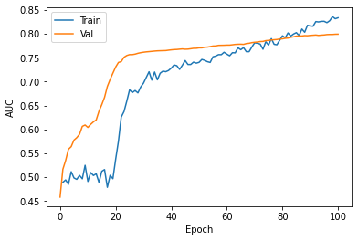

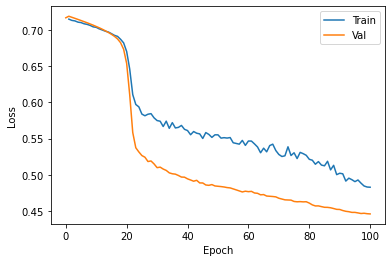

```python
# plot the AUC
sns.lineplot(x=dtlog.index, y=dtlog.train_auroc, label='Train')
sns.lineplot(x=dtlog.index, y=dtlog.val_auroc, label='Val')
plt.legend()
plt.xlabel('Epoch')
plt.ylabel('AUC')
plt.show()

# plot the loss curve
sns.lineplot(x=dtlog.index, y=dtlog.train_loss, label='Train')
sns.lineplot(x=dtlog.index, y=dtlog.val_loss, label='Val')
plt.legend()
plt.xlabel('Epoch')
plt.ylabel('Loss')
plt.show()
```

## 1 - d. Report labeled Confusion Matrix and the evaluation metrics in the validation dataset, including: precision, recall, accuracy, F1 score, and AUC.

### Make predictions

- Reference: TA's Demo

```python
vv = PandasDataset(dt_val_x) # use different dataloader because if we just want to make prediction on the un-seen data, unlabeled dataset, you do not have outcome and only have features
val_loader_pred = DataLoader(vv, batch_size=64, shuffle=False)

val_pred = torch.cat(trainer.predict(model, dataloaders=val_loader_pred)) # Combine the predictions (unnormalized output) from dfferent batches
val_pred.shape
```

```
torch.Size([200, 2])
```

```python
# Convert to normalized predictions
val_pred_prob = torch.softmax(val_pred, dim = 1) # predictive probabilit for each class
val_pred_prob
```

```
tensor([[0.9289, 0.0711],
        [0.7303, 0.2697],
        [0.9088, 0.0912],
        [0.9001, 0.0999],
        [0.8526, 0.1474],
        [0.4958, 0.5042],
        [0.5758, 0.4242],
        [0.9668, 0.0332],
        [0.4969, 0.5031],
        [0.8464, 0.1536],
        [0.6889, 0.3111],
        [0.8849, 0.1151],
        [0.9543, 0.0457],
        [0.9510, 0.0490],
        [0.9732, 0.0268],
        [0.8565, 0.1435],
        [0.6004, 0.3996],
        [0.9716, 0.0284],
        [0.8824, 0.1176],
        [0.4966, 0.5034],
        [0.5259, 0.4741],
        [0.4957, 0.5043],
        [0.4957, 0.5043],
        [0.5570, 0.4430],
        [0.4958, 0.5042],
        [0.9508, 0.0492],
        [0.7221, 0.2779],
        [0.9509, 0.0491],
        [0.6821, 0.3179],
        [0.9712, 0.0288],
        [0.9203, 0.0797],
        [0.8000, 0.2000],
        [0.5065, 0.4935],
        [0.9602, 0.0398],
        [0.9815, 0.0185],
        [0.7574, 0.2426],
        [0.8846, 0.1154],
        [0.4971, 0.5029],
        [0.8711, 0.1289],
        [0.9461, 0.0539],
```

[output cut: 145 more lines]

```
        [0.7688, 0.2312],
        [0.4961, 0.5039],
        [0.9122, 0.0878],
        [0.8619, 0.1381],
        [0.5108, 0.4892],
        [0.9006, 0.0994],
        [0.9243, 0.0757],
        [0.8801, 0.1199],
        [0.4957, 0.5043],
        [0.8021, 0.1979],
        [0.6986, 0.3014],
        [0.9082, 0.0918],
        [0.9811, 0.0189],
        [0.9259, 0.0741],
        [0.8944, 0.1056]])
```

```python
val_pred_class = torch.softmax(val_pred, dim = 1).argmax(1)
val_pred_class
```

```
tensor([0, 0, 0, 0, 0, 1, 0, 0, 1, 0, 0, 0, 0, 0, 0, 0, 0, 0, 0, 1, 0, 1, 1, 0,
        1, 0, 0, 0, 0, 0, 0, 0, 0, 0, 0, 0, 0, 1, 0, 0, 0, 0, 0, 1, 0, 0, 1, 0,
        0, 0, 0, 0, 0, 0, 0, 0, 0, 0, 0, 0, 0, 0, 0, 0, 0, 1, 0, 0, 0, 0, 1, 0,
        1, 1, 0, 0, 0, 0, 0, 0, 0, 0, 0, 0, 0, 0, 0, 0, 0, 0, 0, 0, 0, 0, 0, 0,
        0, 1, 0, 0, 0, 1, 1, 0, 0, 0, 0, 1, 0, 0, 0, 0, 1, 0, 0, 0, 1, 0, 0, 0,
        0, 1, 0, 1, 0, 1, 0, 0, 0, 0, 0, 0, 1, 0, 0, 0, 0, 0, 0, 0, 0, 1, 1, 0,
        0, 0, 0, 0, 0, 0, 0, 0, 0, 0, 0, 0, 0, 0, 1, 0, 0, 0, 0, 0, 1, 1, 0, 0,
        0, 0, 0, 0, 0, 0, 0, 1, 1, 1, 0, 0, 0, 0, 0, 0, 0, 0, 1, 0, 0, 0, 0, 0,
        0, 1, 0, 0, 0, 0, 0, 0])
```

```python
# Load Module
from sklearn.metrics import f1_score, accuracy_score, recall_score, confusion_matrix, roc_auc_score
from sklearn.metrics import plot_confusion_matrix
import matplotlib.pyplot as plt
```

#### Report metrics

```python
precision_val = tp / (tp + fp)
recall_val = recall_score(dt_val_y, val_pred_class.numpy())
accuracy_val = accuracy_score(dt_val_y, val_pred_class.numpy())
F1_val = f1_score(dt_val_y, val_pred_class.numpy())
AUC_val = roc_auc_score(dt_val_y, val_pred_prob.numpy()[:, 1])
ConF_MaX = confusion_matrix(dt_val_y, val_pred_class.numpy())
ConF_MaX_plot = pd.DataFrame(ConF_MaX,
                    index=['True: better prognosis', 'True: worse prognosis'],
                    columns=['Pred: better prognosis', 'Pred: worse prognosis'])

print('Precision: ',precision_val)
print('Recall: ',recall_val)
print('Accuracy: ',accuracy_val)
print('F1 score: ',F1_val)
print('AUC: ',AUC_val)
print ('Confusion Matrix: ')
print(ConF_MaX_plot)
```

[output not shown]

## 1 - e. Apply your trained model to the Unlabeled Data

```python
df_test = pd.read_csv('BRCA-prognosis-test.csv')
df_test
```

|  | brca1 | brca2 | palb2 | pten | tp53 | atm | cdh1 | chek2 | nbn | nf1 | ... | mtap_mut | ppp2cb_mut | smarcd1_mut | nras_mut | ndfip1_mut | hras_mut | prps2_mut | smarcb1_mut | stmn2_mut | siah1_mut |
| --- | --- | --- | --- | --- | --- | --- | --- | --- | --- | --- | --- | --- | --- | --- | --- | --- | --- | --- | --- | --- | --- |
| 0 | -0.6113 | -0.4112 | -0.5326 | 1.2881 | -1.3982 | -0.2587 | 0.3170 | -0.1585 | -0.9302 | -0.2004 | ... | 0 | 0 | 0 | G12S | 0 | 0 | 0 | 0 | 0 | 0 |
| 1 | -0.7632 | 0.6394 | 1.0946 | -0.7267 | -1.1607 | 1.2332 | -0.6189 | 0.3389 | 3.3672 | 1.7262 | ... | 0 | 0 | 0 | 0 | 0 | 0 | 0 | 0 | 0 | 0 |
| 2 | -0.4674 | -0.4817 | 1.0418 | 0.6514 | 0.5839 | -0.1902 | -0.1550 | -1.1869 | -0.6927 | 1.4632 | ... | 0 | 0 | 0 | 0 | 0 | 0 | 0 | 0 | 0 | 0 |
| 3 | 1.2946 | 0.7721 | -0.9238 | 0.3801 | -0.3273 | -1.1697 | 0.7206 | 1.8837 | -1.4707 | -0.6701 | ... | 0 | 0 | 0 | 0 | 0 | 0 | 0 | 0 | 0 | 0 |
| 4 | -1.0671 | -0.2272 | 0.5382 | -1.4913 | 2.7068 | -0.8004 | -0.7550 | 1.9918 | -0.2418 | -0.9464 | ... | 0 | 0 | 0 | 0 | 0 | 0 | 0 | 0 | 0 | 0 |
| ... | ... | ... | ... | ... | ... | ... | ... | ... | ... | ... | ... | ... | ... | ... | ... | ... | ... | ... | ... | ... | ... |
| 495 | -0.1113 | -0.9719 | -1.3743 | 0.5981 | 0.0933 | -0.6940 | 0.1871 | 0.1299 | 1.5912 | -1.4806 | ... | 0 | 0 | 0 | 0 | 0 | 0 | 0 | 0 | 0 | 0 |
| 496 | 1.0041 | -1.2991 | -0.3390 | -0.9913 | 0.9715 | -1.9011 | 0.0309 | -0.8254 | 0.1091 | 0.6994 | ... | 0 | 0 | 0 | 0 | 0 | 0 | 0 | 0 | 0 | 0 |
| 497 | -1.1469 | 0.4460 | 0.2880 | -0.9857 | -0.6334 | -0.9991 | 0.2086 | 1.3829 | -0.1830 | 0.0712 | ... | 0 | 0 | 0 | 0 | 0 | 0 | 0 | 0 | 0 | 0 |
| 498 | -0.7404 | -0.6993 | -1.0944 | -1.2068 | -0.9220 | 1.5662 | 0.8884 | -0.1025 | -1.6279 | -0.9392 | ... | 0 | 0 | 0 | 0 | 0 | 0 | 0 | 0 | 0 | 0 |
| 499 | 0.3856 | 0.6144 | 0.6692 | -0.0430 | -0.2806 | -0.7802 | -0.4089 | 0.3448 | 0.5950 | 0.7740 | ... | 0 | 0 | 0 | 0 | 0 | 0 | 0 | 0 | 0 | 0 |

500 rows × 662 columns

```python
sum(list(df_test.isnull().sum()))
```

```
0
```

- No missing values in Unlabeled Data.

```python
#  convert all string values in these features to numeric values
for col in col_names_mutGene:
    df_test[col] = df_test[col].apply(lambda x: 0 if (x=='0' or x==0) else 1)
```

```python
# Select Target features
target_col_forTest = target_col.copy()
target_col_forTest.remove('outcome')
len(target_col_forTest)

df_test2 = df_test[target_col_forTest].copy()
df_test2.shape
```

```
(500, 254)
```

```python
# normalize continuous features
for i in col_names_Gene:
    df_test2.loc[:,i] = normalization_func(df_test2.loc[:,i])

df_test2.describe()
```

|  | pten | cdh1 | chek2 | nf1 | bard1 | mlh1 | msh6 | epcam | rbl1 | ccna1 | ... | ncor1_mut | stab2_mut | rb1_mut | kdm6a_mut | pbrm1_mut | smad4_mut | prkcq_mut | map3k13_mut | gh1_mut | magea8_mut |
| --- | --- | --- | --- | --- | --- | --- | --- | --- | --- | --- | --- | --- | --- | --- | --- | --- | --- | --- | --- | --- | --- |
| count | 5.000000e+02 | 5.000000e+02 | 5.000000e+02 | 5.000000e+02 | 5.000000e+02 | 5.000000e+02 | 5.000000e+02 | 5.000000e+02 | 5.000000e+02 | 5.000000e+02 | ... | 500.000000 | 500.000000 | 500.00000 | 500.00000 | 500.000000 | 500.000000 | 500.000000 | 500.000000 | 500.000000 | 500.000000 |
| mean | 1.421085e-17 | 1.065814e-17 | -5.329071e-18 | -2.842171e-17 | 1.065814e-17 | 3.552714e-18 | -1.065814e-17 | -8.881784e-18 | -5.329071e-18 | -7.105427e-18 | ... | 0.032000 | 0.062000 | 0.02200 | 0.02200 | 0.016000 | 0.014000 | 0.010000 | 0.008000 | 0.006000 | 0.004000 |
| std | 1.001002e+00 | 1.001002e+00 | 1.001002e+00 | 1.001002e+00 | 1.001002e+00 | 1.001002e+00 | 1.001002e+00 | 1.001002e+00 | 1.001002e+00 | 1.001002e+00 | ... | 0.176176 | 0.241397 | 0.14683 | 0.14683 | 0.125601 | 0.117608 | 0.099598 | 0.089173 | 0.077304 | 0.063182 |
| min | -5.428672e+00 | -3.050453e+00 | -2.100484e+00 | -2.365425e+00 | -2.868891e+00 | -5.304116e+00 | -2.663288e+00 | -1.882729e+00 | -2.344140e+00 | -1.261457e+00 | ... | 0.000000 | 0.000000 | 0.00000 | 0.00000 | 0.000000 | 0.000000 | 0.000000 | 0.000000 | 0.000000 | 0.000000 |
| 25% | -5.687240e-01 | -4.355133e-01 | -7.392572e-01 | -6.892045e-01 | -6.787414e-01 | -5.895867e-01 | -6.868272e-01 | -6.829077e-01 | -6.565924e-01 | -4.763497e-01 | ... | 0.000000 | 0.000000 | 0.00000 | 0.00000 | 0.000000 | 0.000000 | 0.000000 | 0.000000 | 0.000000 | 0.000000 |
| 50% | 1.057546e-01 | 9.570715e-02 | -1.504834e-01 | -7.905495e-02 | -4.782878e-02 | 1.235139e-01 | -8.399092e-02 | -1.444286e-01 | -1.609575e-01 | -2.222191e-01 | ... | 0.000000 | 0.000000 | 0.00000 | 0.00000 | 0.000000 | 0.000000 | 0.000000 | 0.000000 | 0.000000 | 0.000000 |
| 75% | 6.299958e-01 | 6.373637e-01 | 4.946314e-01 | 6.371382e-01 | 6.564663e-01 | 6.527362e-01 | 5.523078e-01 | 4.910615e-01 | 4.804253e-01 | 9.697794e-02 | ... | 0.000000 | 0.000000 | 0.00000 | 0.00000 | 0.000000 | 0.000000 | 0.000000 | 0.000000 | 0.000000 | 0.000000 |
| max | 3.304990e+00 | 2.770672e+00 | 4.340576e+00 | 5.785557e+00 | 2.998663e+00 | 3.387827e+00 | 3.914279e+00 | 6.717527e+00 | 4.163356e+00 | 8.896280e+00 | ... | 1.000000 | 1.000000 | 1.00000 | 1.00000 | 1.000000 | 1.000000 | 1.000000 | 1.000000 | 1.000000 | 1.000000 |

8 rows × 254 columns

```python
# make predictions
testtest = PandasDataset(df_test2)
test_loader_pred = DataLoader(testtest, batch_size=64, shuffle=False)

# Combine the unnormalized predictions from dfferent batches
test_pred = torch.cat(trainer.predict(model, dataloaders=test_loader_pred))

# predictive probabilit for each class
test_pred_prob = torch.softmax(test_pred, dim = 1)
```

```python
df_pred = pd.DataFrame(test_pred_prob[:,1])
df_pred
```

|  | 0 |
| --- | --- |
| 0 | 0.136517 |
| 1 | 0.388557 |
| 2 | 0.260325 |
| 3 | 0.391593 |
| 4 | 0.367849 |
| ... | ... |
| 495 | 0.362117 |
| 496 | 0.503329 |
| 497 | 0.504274 |
| 498 | 0.496184 |
| 499 | 0.036131 |

500 rows × 1 columns

```python
# save the predictions
df_pred.to_csv('F0034WQ_prediction.csv', index=False, header = False)
```

# 2. t-SNE and UMAP for Data Visualization

```python
df = pd.read_csv('five-cancers-gene-expression.csv')
df
```

|  | Patient | Cancer | gene_13968 | gene_18617 | gene_20131 | gene_12738 | gene_5337 | gene_20496 | gene_3408 | gene_15234 | ... | gene_4911 | gene_4915 | gene_521 | gene_8588 | gene_7758 | gene_7221 | gene_8787 | gene_12582 | gene_19923 | gene_7505 |
| --- | --- | --- | --- | --- | --- | --- | --- | --- | --- | --- | --- | --- | --- | --- | --- | --- | --- | --- | --- | --- | --- |
| 0 | sample_100 | BRCA | 8.591709 | 0.0 | 7.092408 | 9.142789 | 5.805636 | 7.033654 | 9.370833 | 5.209453 | ... | 8.238725 | 9.715028 | 8.106783 | 0.341075 | 9.342075 | 8.044028 | 0.00000 | 0.0 | 0.000000 | 0.616640 |
| 1 | sample_102 | BRCA | 8.801388 | 0.0 | 5.891225 | 8.094901 | 3.039454 | 5.237969 | 9.180374 | 4.675483 | ... | 5.235980 | 8.728067 | 7.949056 | 0.366140 | 9.433381 | 5.422445 | 0.00000 | 0.0 | 2.632198 | 9.340010 |
| 2 | sample_111 | BRCA | 8.612400 | 0.0 | 6.125393 | 7.892027 | 4.830783 | 5.890634 | 9.768285 | 5.335144 | ... | 6.274644 | 9.391233 | 7.007846 | 0.000000 | 9.637172 | 6.409890 | 0.00000 | 0.0 | 0.412294 | 9.418873 |
| 3 | sample_114 | BRCA | 8.293775 | 0.0 | 5.747242 | 8.353469 | 3.768322 | 5.979115 | 9.321678 | 6.105724 | ... | 8.646094 | 9.354020 | 7.111772 | 0.000000 | 9.209232 | 8.052677 | 0.00000 | 0.0 | 0.000000 | 8.573837 |
| 4 | sample_118 | BRCA | 8.776821 | 0.0 | 7.026391 | 7.372264 | 3.824371 | 5.639357 | 9.588062 | 5.239612 | ... | 10.725682 | 9.139298 | 8.196587 | 0.000000 | 9.473982 | 4.245861 | 0.00000 | 0.0 | 0.273814 | 9.252138 |
| ... | ... | ... | ... | ... | ... | ... | ... | ... | ... | ... | ... | ... | ... | ... | ... | ... | ... | ... | ... | ... | ... |
| 745 | sample_9 | PRAD | 7.499455 | 0.0 | 4.953819 | 8.387251 | 5.960875 | 3.314972 | 9.575887 | 6.062892 | ... | 3.595014 | 10.122841 | 2.635987 | 0.724214 | 9.816036 | 1.204141 | 0.00000 | 0.0 | 5.098108 | 11.078831 |
| 746 | sample_90 | PRAD | 8.203402 | 0.0 | 5.574053 | 8.475474 | 2.212320 | 4.580477 | 8.733324 | 7.489286 | ... | 4.065917 | 9.722710 | 2.212320 | 0.000000 | 9.099471 | 6.724991 | 0.00000 | 0.0 | 0.000000 | 10.380374 |
| 747 | sample_91 | PRAD | 8.278584 | 0.0 | 5.918167 | 7.897331 | 4.232231 | 3.928039 | 8.348648 | 6.776630 | ... | 5.962177 | 9.900328 | 5.174750 | 0.000000 | 9.326582 | 8.458357 | 0.00000 | 0.0 | 0.000000 | 12.146238 |
| 748 | sample_95 | PRAD | 8.240820 | 0.0 | 5.603068 | 7.973227 | 1.957989 | 3.537793 | 9.373994 | 5.225965 | ... | 1.288418 | 9.842309 | 3.424600 | 0.000000 | 9.055936 | 6.034674 | 1.05797 | 0.0 | 2.413540 | 11.684416 |
| 749 | sample_98 | PRAD | 8.195097 | 0.0 | 5.784674 | 7.457011 | 5.051124 | 4.156024 | 9.805568 | 6.005330 | ... | 9.477117 | 9.314243 | 1.382778 | 0.000000 | 9.262273 | 5.784674 | 2.07567 | 0.0 | 2.402504 | 10.197991 |

750 rows × 77 columns

## 2-a. Apply t-SNE in the scikit-learn library with n_components=2

```python
df_2 = df.drop(['Patient','Cancer'],axis=1).copy()
df_2
```

|  | gene_13968 | gene_18617 | gene_20131 | gene_12738 | gene_5337 | gene_20496 | gene_3408 | gene_15234 | gene_2833 | gene_6139 | ... | gene_4911 | gene_4915 | gene_521 | gene_8588 | gene_7758 | gene_7221 | gene_8787 | gene_12582 | gene_19923 | gene_7505 |
| --- | --- | --- | --- | --- | --- | --- | --- | --- | --- | --- | --- | --- | --- | --- | --- | --- | --- | --- | --- | --- | --- |
| 0 | 8.591709 | 0.0 | 7.092408 | 9.142789 | 5.805636 | 7.033654 | 9.370833 | 5.209453 | 2.662957 | 9.716420 | ... | 8.238725 | 9.715028 | 8.106783 | 0.341075 | 9.342075 | 8.044028 | 0.00000 | 0.0 | 0.000000 | 0.616640 |
| 1 | 8.801388 | 0.0 | 5.891225 | 8.094901 | 3.039454 | 5.237969 | 9.180374 | 4.675483 | 3.039454 | 9.393041 | ... | 5.235980 | 8.728067 | 7.949056 | 0.366140 | 9.433381 | 5.422445 | 0.00000 | 0.0 | 2.632198 | 9.340010 |
| 2 | 8.612400 | 0.0 | 6.125393 | 7.892027 | 4.830783 | 5.890634 | 9.768285 | 5.335144 | 4.912295 | 10.056543 | ... | 6.274644 | 9.391233 | 7.007846 | 0.000000 | 9.637172 | 6.409890 | 0.00000 | 0.0 | 0.412294 | 9.418873 |
| 3 | 8.293775 | 0.0 | 5.747242 | 8.353469 | 3.768322 | 5.979115 | 9.321678 | 6.105724 | 2.519743 | 9.776866 | ... | 8.646094 | 9.354020 | 7.111772 | 0.000000 | 9.209232 | 8.052677 | 0.00000 | 0.0 | 0.000000 | 8.573837 |
| 4 | 8.776821 | 0.0 | 7.026391 | 7.372264 | 3.824371 | 5.639357 | 9.588062 | 5.239612 | 4.041331 | 9.846992 | ... | 10.725682 | 9.139298 | 8.196587 | 0.000000 | 9.473982 | 4.245861 | 0.00000 | 0.0 | 0.273814 | 9.252138 |
| ... | ... | ... | ... | ... | ... | ... | ... | ... | ... | ... | ... | ... | ... | ... | ... | ... | ... | ... | ... | ... | ... |
| 745 | 7.499455 | 0.0 | 4.953819 | 8.387251 | 5.960875 | 3.314972 | 9.575887 | 6.062892 | 3.141433 | 9.556031 | ... | 3.595014 | 10.122841 | 2.635987 | 0.724214 | 9.816036 | 1.204141 | 0.00000 | 0.0 | 5.098108 | 11.078831 |
| 746 | 8.203402 | 0.0 | 5.574053 | 8.475474 | 2.212320 | 4.580477 | 8.733324 | 7.489286 | 3.957599 | 9.102653 | ... | 4.065917 | 9.722710 | 2.212320 | 0.000000 | 9.099471 | 6.724991 | 0.00000 | 0.0 | 0.000000 | 10.380374 |
| 747 | 8.278584 | 0.0 | 5.918167 | 7.897331 | 4.232231 | 3.928039 | 8.348648 | 6.776630 | 1.740453 | 8.867072 | ... | 5.962177 | 9.900328 | 5.174750 | 0.000000 | 9.326582 | 8.458357 | 0.00000 | 0.0 | 0.000000 | 12.146238 |
| 748 | 8.240820 | 0.0 | 5.603068 | 7.973227 | 1.957989 | 3.537793 | 9.373994 | 5.225965 | 5.901745 | 10.104114 | ... | 1.288418 | 9.842309 | 3.424600 | 0.000000 | 9.055936 | 6.034674 | 1.05797 | 0.0 | 2.413540 | 11.684416 |
| 749 | 8.195097 | 0.0 | 5.784674 | 7.457011 | 5.051124 | 4.156024 | 9.805568 | 6.005330 | 7.053470 | 9.985643 | ... | 9.477117 | 9.314243 | 1.382778 | 0.000000 | 9.262273 | 5.784674 | 2.07567 | 0.0 | 2.402504 | 10.197991 |

750 rows × 75 columns

```python
# Apply t-SNE
from sklearn.manifold import TSNE
df_2_tsne = TSNE(n_components=2).fit_transform(df_2)
df_2_tsne
```

```
array([[ 14.123409 ,  10.04349  ],
       [ -3.0648112,  16.480053 ],
       [ -1.494606 ,  17.418083 ],
       ...,
       [-26.139647 ,   8.773267 ],
       [-24.299377 ,   5.1945233],
       [-16.949133 ,   8.053046 ]], dtype=float32)
```

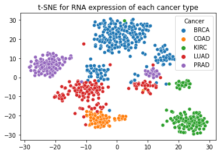

```python
# Scatter plot
import seaborn as sns
import matplotlib.pyplot as plt

sns.scatterplot(x= df_2_tsne[:,0], y= df_2_tsne[:,1], hue= df['Cancer'])
plt.title('t-SNE for RNA expression of each cancer type')
```

According to the plot, we can see t-SNE can map high dimensional data to 2 dimensional space and 5 cancer cell types are separated very well. However, we can see some cancer types, such as PRAD, LUAD, BRCA, and KIRC have multiple clusters. I think these small clusters might be the subtypes for those main cancer types. Also, we can see some samples of LUAD are closer to BRCA compared with LUAD. I think these samples might be outliers.

## 2-b. Repeat the procedures in part a, with additional hyperparameter tuning

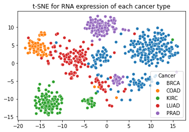

```python
df_2_tsne_2 = TSNE(n_components=2, perplexity = 60, learning_rate = 500, n_iter = 1500).fit_transform(df_2)

sns.scatterplot(x= df_2_tsne_2[:,0], y= df_2_tsne_2[:,1], hue= df['Cancer'])
plt.title('t-SNE for RNA expression of each cancer type')
```

## 2-c. Apply UMAP on the same dataset.

- Reference: https://umap-learn.readthedocs.io/en/latest/basic_usage.html
- Reference: https://umap-learn.readthedocs.io/en/latest/parameters.html

```python
# Load module
import umap
```

```
[Text(0.5, 1.0, 'UMAP n_neighbors = 20, min_dist = 0.8')]
```

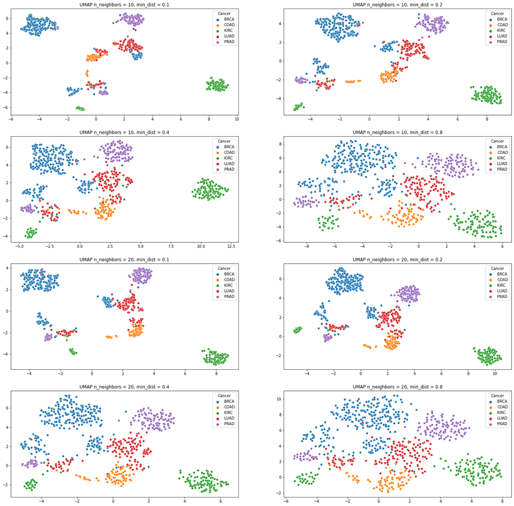

```python
fig, axes = plt.subplots(4, 2, figsize=(24, 24))

# UMAP n_neighbors = 10
df_UMAP1 = umap.UMAP(n_components=2, metric='euclidean', n_neighbors = 10, min_dist = 0.1).fit_transform(df_2)
sns.scatterplot(x= df_UMAP1[:,0], y= df_UMAP1[:,1], hue= df['Cancer'], ax=axes[0,0]).set( title = "UMAP n_neighbors = 10, min_dist = 0.1")

df_UMAP2 = umap.UMAP(n_components=2, metric='euclidean', n_neighbors = 10, min_dist = 0.2).fit_transform(df_2)
sns.scatterplot(x= df_UMAP2[:,0], y= df_UMAP2[:,1], hue= df['Cancer'], ax=axes[0,1]).set( title = "UMAP n_neighbors = 10, min_dist = 0.2")

df_UMAP3 = umap.UMAP(n_components=2, metric='euclidean', n_neighbors = 10, min_dist = 0.4).fit_transform(df_2)
sns.scatterplot(x= df_UMAP3[:,0], y= df_UMAP3[:,1], hue= df['Cancer'], ax=axes[1,0]).set( title = "UMAP n_neighbors = 10, min_dist = 0.4")

df_UMAP4 = umap.UMAP(n_components=2, metric='euclidean', n_neighbors = 10, min_dist = 0.8).fit_transform(df_2)
sns.scatterplot(x= df_UMAP4[:,0], y= df_UMAP4[:,1], hue= df['Cancer'], ax=axes[1,1]).set( title = "UMAP n_neighbors = 10, min_dist = 0.8")


# UMAP n_neighbors = 20
df_UMAP5 = umap.UMAP(n_components=2, metric='euclidean', n_neighbors = 20, min_dist = 0.1).fit_transform(df_2)
sns.scatterplot(x= df_UMAP5[:,0], y= df_UMAP5[:,1], hue= df['Cancer'], ax=axes[2,0]).set( title = "UMAP n_neighbors = 20, min_dist = 0.1")

df_UMAP6 = umap.UMAP(n_components=2, metric='euclidean', n_neighbors = 20, min_dist = 0.2).fit_transform(df_2)
sns.scatterplot(x= df_UMAP6[:,0], y= df_UMAP6[:,1], hue= df['Cancer'], ax=axes[2,1]).set( title = "UMAP n_neighbors = 20, min_dist = 0.2")

df_UMAP7 = umap.UMAP(n_components=2, metric='euclidean', n_neighbors = 20, min_dist = 0.4).fit_transform(df_2)
sns.scatterplot(x= df_UMAP7[:,0], y= df_UMAP7[:,1], hue= df['Cancer'], ax=axes[3,0]).set( title = "UMAP n_neighbors = 20, min_dist = 0.4")

df_UMAP8 = umap.UMAP(n_components=2, metric='euclidean', n_neighbors = 20, min_dist = 0.8).fit_transform(df_2)
sns.scatterplot(x= df_UMAP8[:,0], y= df_UMAP8[:,1], hue= df['Cancer'], ax=axes[3,1]).set( title = "UMAP n_neighbors = 20, min_dist = 0.8")
```

```
[Text(0.5, 1.0, 'UMAP n_neighbors = 80, min_dist = 0.8')]
```

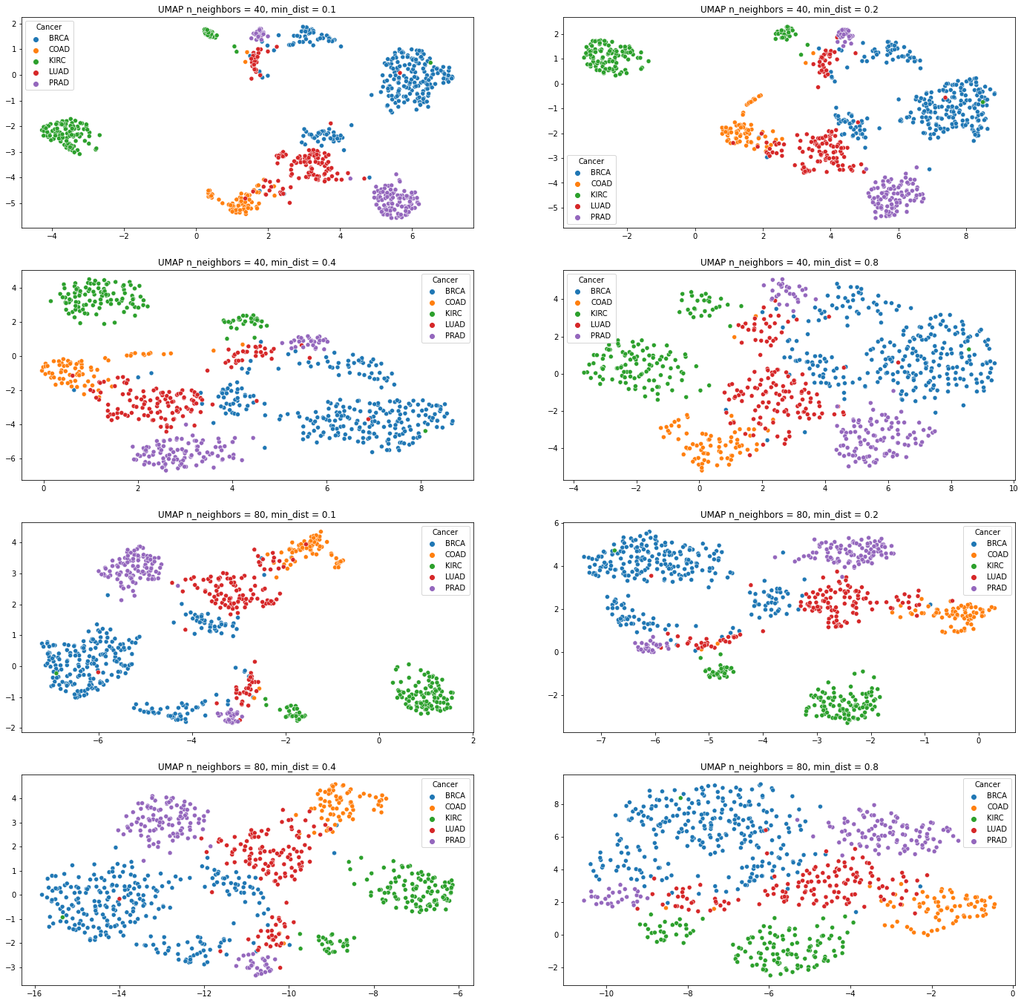

```python
fig, axes = plt.subplots(4, 2, figsize=(24, 24))

# n_neighbors = 40
df_UMAP9 = umap.UMAP(n_components=2, metric='euclidean', n_neighbors = 40, min_dist = 0.1).fit_transform(df_2)
sns.scatterplot(x= df_UMAP9[:,0], y= df_UMAP9[:,1], hue= df['Cancer'], ax=axes[0,0]).set( title = "UMAP n_neighbors = 40, min_dist = 0.1")

df_UMAP10 = umap.UMAP(n_components=2, metric='euclidean', n_neighbors = 40, min_dist = 0.2).fit_transform(df_2)
sns.scatterplot(x= df_UMAP10[:,0], y= df_UMAP10[:,1], hue= df['Cancer'], ax=axes[0,1]).set( title = "UMAP n_neighbors = 40, min_dist = 0.2")

df_UMAP11 = umap.UMAP(n_components=2, metric='euclidean', n_neighbors = 40, min_dist = 0.4).fit_transform(df_2)
sns.scatterplot(x= df_UMAP11[:,0], y= df_UMAP11[:,1], hue= df['Cancer'], ax=axes[1,0]).set( title = "UMAP n_neighbors = 40, min_dist = 0.4")

df_UMAP12 = umap.UMAP(n_components=2, metric='euclidean', n_neighbors = 40, min_dist = 0.8).fit_transform(df_2)
sns.scatterplot(x= df_UMAP12[:,0], y= df_UMAP12[:,1], hue= df['Cancer'], ax=axes[1,1]).set( title = "UMAP n_neighbors = 40, min_dist = 0.8")

# UMAP n_neighbors = 80
df_UMAP13 = umap.UMAP(n_components=2, metric='euclidean', n_neighbors = 80, min_dist = 0.1).fit_transform(df_2)
sns.scatterplot(x= df_UMAP13[:,0], y= df_UMAP13[:,1], hue= df['Cancer'], ax=axes[2,0]).set( title = "UMAP n_neighbors = 80, min_dist = 0.1")

df_UMAP14 = umap.UMAP(n_components=2, metric='euclidean', n_neighbors = 80, min_dist = 0.2).fit_transform(df_2)
sns.scatterplot(x= df_UMAP14[:,0], y= df_UMAP14[:,1], hue= df['Cancer'], ax=axes[2,1]).set( title = "UMAP n_neighbors = 80, min_dist = 0.2")

df_UMAP15 = umap.UMAP(n_components=2, metric='euclidean', n_neighbors = 80, min_dist = 0.4).fit_transform(df_2)
sns.scatterplot(x= df_UMAP15[:,0], y= df_UMAP15[:,1], hue= df['Cancer'], ax=axes[3,0]).set( title = "UMAP n_neighbors = 80, min_dist = 0.4")

df_UMAP16 = umap.UMAP(n_components=2, metric='euclidean', n_neighbors = 80, min_dist = 0.8).fit_transform(df_2)
sns.scatterplot(x= df_UMAP16[:,0], y= df_UMAP16[:,1], hue= df['Cancer'], ax=axes[3,1]).set( title = "UMAP n_neighbors = 80, min_dist = 0.8")
```

Based on https://umap-learn.readthedocs.io/en/latest/parameters.html, n_neighbors controls how UMAP balances local versus global structure in the data. Low values of n_neighbors will force UMAP to concentrate on a very local structure, and too large values lose detail structure. As a result, with n_neighbors increasing, each cancer type cluster is not compacted/dense compared with low n_neighbors values. The min_dist controls how tightly UMAP is allowed to pack points together. So in my opinion, I think the best combination of hyperparameters is n_components=2, metric='euclidean', n_neighbors = 20, and min_dist = 0.2

## 2-d. Estimate the time it took to fit t-SNE and UMAP on simulated datasets.

- Reference: https://umap-learn.readthedocs.io/en/latest/parameters.html

```python
import time

n_obs = [10,100,1000,10000]
n_features = [10,30,100,300]

observation_number = []
feature_number = []
t_SNE_seconds = []
UMAP_seconds = []

method_tSNE = TSNE()
method_UMAP = umap.UMAP()

for i in n_obs:
    for j in n_features:
        observation_number.append(i)
        feature_number.append(j)
        data = np.random.rand(i, j)

        start_tSNE = time.time()
        method_tSNE.fit_transform(data)
        end_tSNE = time.time()
        total_tSNE = end_tSNE - start_tSNE
        t_SNE_seconds.append(total_tSNE)

        start_UMAP = time.time()
        method_UMAP.fit_transform(data)
        end_UMAP = time.time()
        total_UMAP = end_UMAP - start_UMAP
        UMAP_seconds.append(total_UMAP)
```

[output not shown]

[output cut: 19 more lines]

[output not shown]

```python
result = pd.DataFrame()
result['Number of Observations'] = observation_number
result['Number of Features'] = feature_number
result['t-SNE running time (seconds)'] = t_SNE_seconds
result['UMAP running time (seconds)'] = UMAP_seconds
result
```

|  | Number of Observations | Number of Features | t-SNE running time (seconds) | UMAP running time (seconds) |
| --- | --- | --- | --- | --- |
| 0 | 10 | 10 | 0.200663 | 0.021092 |
| 1 | 10 | 30 | 0.222042 | 0.018828 |
| 2 | 10 | 100 | 0.128698 | 0.018400 |
| 3 | 10 | 300 | 0.185330 | 0.018491 |
| 4 | 100 | 10 | 0.487030 | 0.176302 |
| 5 | 100 | 30 | 0.484668 | 0.187400 |
| 6 | 100 | 100 | 0.656883 | 0.181235 |
| 7 | 100 | 300 | 0.477384 | 0.182112 |
| 8 | 1000 | 10 | 6.442281 | 1.522532 |
| 9 | 1000 | 30 | 6.077269 | 1.551414 |
| 10 | 1000 | 100 | 8.740793 | 1.770407 |
| 11 | 1000 | 300 | 7.483002 | 1.772822 |
| 12 | 10000 | 10 | 87.184475 | 22.233955 |
| 13 | 10000 | 30 | 102.072792 | 19.314443 |
| 14 | 10000 | 100 | 120.566159 | 21.768741 |
| 15 | 10000 | 300 | 159.426440 | 20.267445 |

- UMAP is faster than t-SNE!!